# Predicting Mortality in Heart Failure Patients

Author

DSCI 522 Group 41

# Summary

In this project, we asked whether we can predict if a patient with heart failure will die during the follow-up period from routinely collected clinical measurements. Using the Heart Failure Clinical Records data set of 299 patients with advanced heart failure, we trained a logistic regression model and compared it with a baseline model that always predicts survival. On the held-out test set, our model achieved an accuracy of 73.3%, a recall of 42.1% and an F1-score of 0.50, correctly identifying 8 of the 19 patients who died. Although the model performs better than the baseline, its low recall means it misses most patients who died, so it is not reliable enough to guide clinical decisions on its own. Our results are limited by the small data set, which comes from a single hospital and includes only patients with advanced disease, and by the small number of deaths in the test set. Future work could explore other models and lower classification thresholds to identify more high-risk patients.

# Introduction

## Background

Heart failure is a chronic condition in which the heart cannot pump enough blood to meet the body’s needs, reducing the flow of blood and oxygen to the body and vital organs. This occurs when the heart becomes weakened, stiff, or damaged (Cardiac Services BC, n.d.). The most common cause is damage to the heart muscle from a heart attack or from blocked arteries around the heart; other causes include high blood pressure, heart valve problems, and congenital heart disease (Cardiac Services BC, n.d.). Heart failure currently has no cure; instead, it is managed by monitoring symptoms and weight, limiting sodium and fluid intake, controlling blood pressure, and taking medication (Cardiac Services BC, n.d.).

There is no single test that diagnoses heart failure; clinicians commonly rely on a combination of blood tests, echocardiograms, chest X-rays, and electrocardiograms (Cardiac Services BC, n.d.). One key measurement is the ejection fraction (EF), the percentage of blood the heart pumps out with each contraction. A normal EF is about 60%, and patients with an EF of 40% or lower are classified as having heart failure with reduced ejection fraction (BC Ministry of Health 2023). Blood tests also provide useful information: serum creatinine reflects how well the kidneys are working, serum sodium measures the sodium level in the blood, creatinine phosphokinase (CPK) is an enzyme released when muscle tissue is damaged, and anaemia indicates a low level of red blood cells or hemoglobin (*Heart Failure Clinical Records* 2020). Previous studies using this data set found that age, kidney function, blood pressure, ejection fraction, and anaemia were significant risk factors for mortality (Ahmad et al. 2017), and that serum creatinine and ejection fraction alone could predict survival well (Chicco and Jurman 2020).

Heart failure is a significant health burden in British Columbia, where about 2% of the population, roughly 137,082 people, were living with diagnosed heart failure in 2020/21, with 18,512 new cases that year (BC Ministry of Health 2023). As the number of people living with heart failure grows, clinicians need ways to identify which diagnosed patients are at the greatest risk of death. A model that predicts mortality from routinely collected clinical measurements could help prioritize these patients for closer follow-up, faster optimization of guideline-directed medical therapy, and timely referral for advanced treatments. This matters because guideline-directed therapy can extend life by several years, but its benefits take months to appear as doses are gradually increased (Cardiac Services BC, n.d.).

## Research Question

The purpose of this project is to answer the following question: can we predict whether a patient with heart failure will die during the follow-up period using their clinical characteristics (such as age, ejection fraction, serum creatinine, and serum sodium)?

## Dataset Description

The data set used in this report is the Heart Failure Clinical Records data set from the UCI Machine Learning Repository (*Heart Failure Clinical Records* 2020), originally collected by Ahmad et al. (2017). It contains the medical records of 299 patients admitted to the Institute of Cardiology and Allied Hospital in Faisalabad, Pakistan, between April and December 2015. All patients were aged 40 or older, had left ventricular systolic dysfunction, and were classified as New York Heart Association (NYHA) class III or IV (Ahmad et al. 2017). The NYHA classification grades heart failure severity from class I (no limitation of physical activity) to class IV (symptoms at rest), so classes III and IV represent patients with advanced disease (American Heart Association, n.d.).

Each row represents one patient. The available variables are age, anaemia, creatinine phosphokinase (CPK), diabetes, ejection fraction, high blood pressure, platelets, serum creatinine, serum sodium, sex, smoking status, and follow-up time. The target variable is whether the patient died during the follow-up period (death event), coded as 1 if the patient died and 0 otherwise. Follow-up time is excluded as a predictor because it is directly linked to the outcome: patients who died early necessarily have shorter follow-up times, so including it would leak information about the target. This question can be addressed with this data set because it contains a clearly defined binary outcome and clinical measurements that are routinely collected in practice. However, because the data come from 299 patients with advanced heart failure at a single hospital, the results may not generalize to patients with milder disease or to other populations.

# Methods

## Python Libraries Import

```python
import pandas as pd
import numpy as np
import matplotlib.pyplot as plt
import seaborn as sns
plot_color = "teal"
```

## Data Import and Preparation

```python
from pathlib import Path

# Define the dataset URL
url = "https://archive.ics.uci.edu/ml/machine-learning-databases/00519/heart_failure_clinical_records_dataset.csv"

# Define the raw data directory
raw_dir = Path("../data/raw")

# Create the directory if it doesn't exist
raw_dir.mkdir(parents=True, exist_ok=True)

# Define the file path
raw_file = raw_dir / "heart_failure_clinical_records_dataset.csv"

# Download and save the raw dataset if it doesn't exist
if not raw_file.exists():
    df = pd.read_csv(url)
    df.to_csv(raw_file, index=False)
else:
    df = pd.read_csv(raw_file)

df.head()
```

|  | age | anaemia | creatinine_phosphokinase | diabetes | ejection_fraction | high_blood_pressure | platelets | serum_creatinine | serum_sodium | sex | smoking | time | DEATH_EVENT |
| --- | --- | --- | --- | --- | --- | --- | --- | --- | --- | --- | --- | --- | --- |
| 0 | 75.0 | 0 | 582 | 0 | 20 | 1 | 265000.00 | 1.9 | 130 | 1 | 0 | 4 | 1 |
| 1 | 55.0 | 0 | 7861 | 0 | 38 | 0 | 263358.03 | 1.1 | 136 | 1 | 0 | 6 | 1 |
| 2 | 65.0 | 0 | 146 | 0 | 20 | 0 | 162000.00 | 1.3 | 129 | 1 | 1 | 7 | 1 |
| 3 | 50.0 | 1 | 111 | 0 | 20 | 0 | 210000.00 | 1.9 | 137 | 1 | 0 | 7 | 1 |
| 4 | 65.0 | 1 | 160 | 1 | 20 | 0 | 327000.00 | 2.7 | 116 | 0 | 0 | 8 | 1 |

## Data Inspection

```python
row_ncol=df.shape
col_names=df.columns
df_n_na=df.isna().sum()
duplicates=df.duplicated().sum()
print(f"The shape(rows and cols) of this df is of dimension: {row_ncol}")
print(f"The features/attributes of this dataframe are : {col_names}")
print(f"The sum of nulls per attributes/features of this dataframe are : {df_n_na}")
print(f"The number of duplicate rows is: {duplicates}")
df.info()
df.describe()
```

```
The shape(rows and cols) of this df is of dimension: (299, 13)
The features/attributes of this dataframe are : Index(['age', 'anaemia', 'creatinine_phosphokinase', 'diabetes',
       'ejection_fraction', 'high_blood_pressure', 'platelets',
       'serum_creatinine', 'serum_sodium', 'sex', 'smoking', 'time',
       'DEATH_EVENT'],
      dtype='str')
The sum of nulls per attributes/features of this dataframe are : age                         0
anaemia                     0
creatinine_phosphokinase    0
diabetes                    0
ejection_fraction           0
high_blood_pressure         0
platelets                   0
serum_creatinine            0
serum_sodium                0
sex                         0
smoking                     0
time                        0
DEATH_EVENT                 0
dtype: int64
The number of duplicate rows is: 0
<class 'pandas.DataFrame'>
RangeIndex: 299 entries, 0 to 298
Data columns (total 13 columns):
 #   Column                    Non-Null Count  Dtype
---  ------                    --------------  -----
 0   age                       299 non-null    float64
 1   anaemia                   299 non-null    int64
 2   creatinine_phosphokinase  299 non-null    int64
 3   diabetes                  299 non-null    int64
 4   ejection_fraction         299 non-null    int64
 5   high_blood_pressure       299 non-null    int64
 6   platelets                 299 non-null    float64
 7   serum_creatinine          299 non-null    float64
 8   serum_sodium              299 non-null    int64
 9   sex                       299 non-null    int64
 10  smoking                   299 non-null    int64
 11  time                      299 non-null    int64
 12  DEATH_EVENT               299 non-null    int64
dtypes: float64(3), int64(10)
memory usage: 30.5 KB
```

|  | age | anaemia | creatinine_phosphokinase | diabetes | ejection_fraction | high_blood_pressure | platelets | serum_creatinine | serum_sodium | sex | smoking | time | DEATH_EVENT |
| --- | --- | --- | --- | --- | --- | --- | --- | --- | --- | --- | --- | --- | --- |
| count | 299.000000 | 299.000000 | 299.000000 | 299.000000 | 299.000000 | 299.000000 | 299.000000 | 299.00000 | 299.000000 | 299.000000 | 299.00000 | 299.000000 | 299.00000 |
| mean | 60.833893 | 0.431438 | 581.839465 | 0.418060 | 38.083612 | 0.351171 | 263358.029264 | 1.39388 | 136.625418 | 0.648829 | 0.32107 | 130.260870 | 0.32107 |
| std | 11.894809 | 0.496107 | 970.287881 | 0.494067 | 11.834841 | 0.478136 | 97804.236869 | 1.03451 | 4.412477 | 0.478136 | 0.46767 | 77.614208 | 0.46767 |
| min | 40.000000 | 0.000000 | 23.000000 | 0.000000 | 14.000000 | 0.000000 | 25100.000000 | 0.50000 | 113.000000 | 0.000000 | 0.00000 | 4.000000 | 0.00000 |
| 25% | 51.000000 | 0.000000 | 116.500000 | 0.000000 | 30.000000 | 0.000000 | 212500.000000 | 0.90000 | 134.000000 | 0.000000 | 0.00000 | 73.000000 | 0.00000 |
| 50% | 60.000000 | 0.000000 | 250.000000 | 0.000000 | 38.000000 | 0.000000 | 262000.000000 | 1.10000 | 137.000000 | 1.000000 | 0.00000 | 115.000000 | 0.00000 |
| 75% | 70.000000 | 1.000000 | 582.000000 | 1.000000 | 45.000000 | 1.000000 | 303500.000000 | 1.40000 | 140.000000 | 1.000000 | 1.00000 | 203.000000 | 1.00000 |
| max | 95.000000 | 1.000000 | 7861.000000 | 1.000000 | 80.000000 | 1.000000 | 850000.000000 | 9.40000 | 148.000000 | 1.000000 | 1.00000 | 285.000000 | 1.00000 |

## Inspect target Variable

```
DEATH_EVENT
0    67.9
1    32.1
Name: proportion, dtype: float64
```

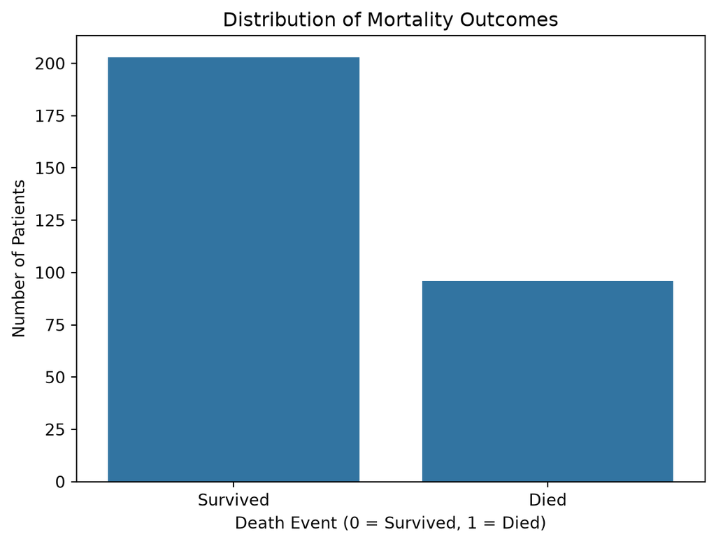

```python
motaility_percentages=df["DEATH_EVENT"].value_counts(normalize=True)*100
print(round(motaility_percentages,1))

#Visualise the target distribution

sns.countplot(data=df, x="DEATH_EVENT")

plt.title("Distribution of Mortality Outcomes")
plt.xlabel("Death Event (0 = Survived, 1 = Died)")
plt.ylabel("Number of Patients")
plt.xticks([0, 1], ["Survived", "Died"])
plt.show()
```

Frome the visual above, the training data contains more patients who survived than died during the follow-up period. ~ 68% survived and 32% experienced a death event, indicating an imbalance in the target classes, with survival being the majority class. This is important for model evaluation because accuracy alone may not adequately capture how well the model identifies patients who died.

## Data Splitting

```python
from sklearn.model_selection import train_test_split

X = df.drop(columns=["DEATH_EVENT", "time"])
y = df["DEATH_EVENT"]

X_train, X_test, y_train, y_test = train_test_split(
    X,
    y,
    test_size=0.2,
    stratify=y,
    random_state=522
)

train_df = X_train.copy()
train_df["DEATH_EVENT"] = y_train

print("Training set:", X_train.shape)
print("Testing set:", X_test.shape)
```

```
Training set: (239, 11)
Testing set: (60, 11)
```

### Saving Processed Data

We save the stratified training and test splits separately, with `DEATH_EVENT` as the outcome and follow-up time excluded. Feature scaling is fitted within the model pipeline during training.

```python
processed_dir = raw_dir.parent / "processed"
processed_dir.mkdir(parents=True, exist_ok=True)

test_df = X_test.copy()
test_df["DEATH_EVENT"] = y_test

train_df.to_csv(processed_dir / "train.csv", index=False)
test_df.to_csv(processed_dir / "test.csv", index=False)
```

## Exploratory Data Analysis : Understanding the Patients Demographics

### Reviewing Outliers and Reason for Not Ignoring Them

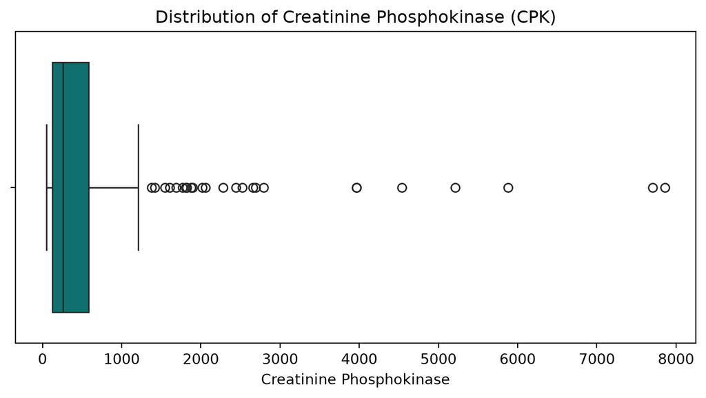

```python
# Boxplot for creatinine phosphokinase (CPK)
plt.figure(figsize=(7, 4))
sns.boxplot(data=train_df, x="creatinine_phosphokinase", color=plot_color)

plt.title("Distribution of Creatinine Phosphokinase (CPK)")
plt.xlabel("Creatinine Phosphokinase")
plt.tight_layout()
plt.show()
```

## Boxplot for platelets

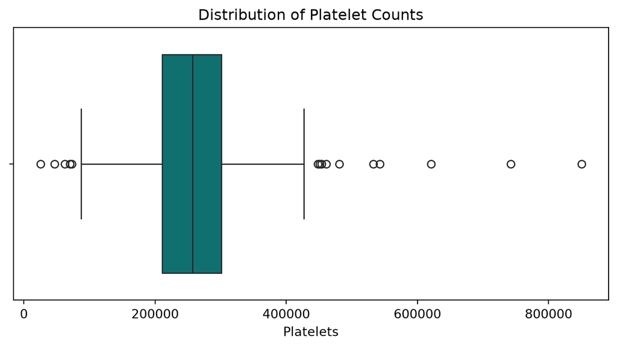

```python
plt.figure(figsize=(7, 4))
sns.boxplot(data=train_df, x="platelets", color=plot_color)

plt.title("Distribution of Platelet Counts")
plt.xlabel("Platelets")
plt.tight_layout()
plt.show()
```

The two boxplots of creatinine phosphokinase (CPK) and platelet counts revealed extreme values in both variables. These observations were retained in the dataset because they may represent genuine clinical measurements rather than data errors. Removing them without clinical justification could result in the loss of meaningful information. We therefore acknowledge these extreme values and retain them for subsequent analysis.

### Heart Failure Patients Distribution by Age

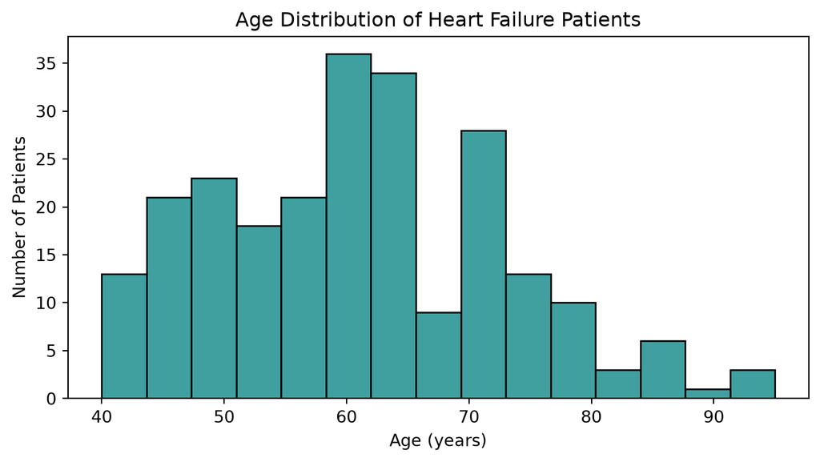

```python
plt.figure(figsize=(7, 4))

sns.histplot(data=train_df, x="age", bins=15,color=plot_color)

plt.title("Age Distribution of Heart Failure Patients")
plt.xlabel("Age (years)")
plt.ylabel("Number of Patients")

plt.tight_layout()
plt.show()
```

The age distribution shows that patients are predominantly between approximately 50 and 75 years old, with the highest concentration around 60–65 years. The distribution is weighted toward older adults, with relatively few patients above 80, which is consistent with heart failure being more common in older populations.

### Heart Failure Patients distribution by sex

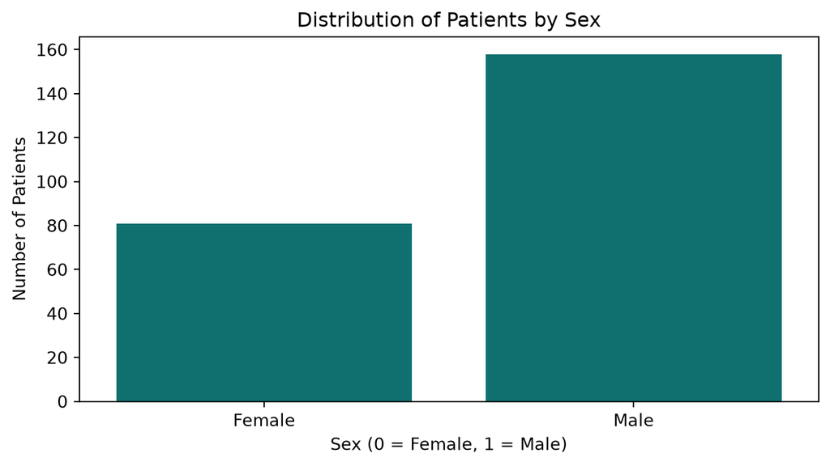

```python
plt.figure(figsize=(7, 4))

sns.countplot(data=train_df, x="sex",color=plot_color)

plt.title("Distribution of Patients by Sex")
plt.xlabel("Sex (0 = Female, 1 = Male)")
plt.ylabel("Number of Patients")
plt.xticks([0, 1], ["Female", "Male"])

plt.tight_layout()
plt.show()
```

The training data contains more male patients (approximately 158) than female patients (approximately 81), meaning males make up the larger proportion of the dataset. This imbalance in sex representation is important to consider when examining mortality patterns, as differences in outcomes between sexes may partly reflect differences in group sizes.

### Mortality by Age

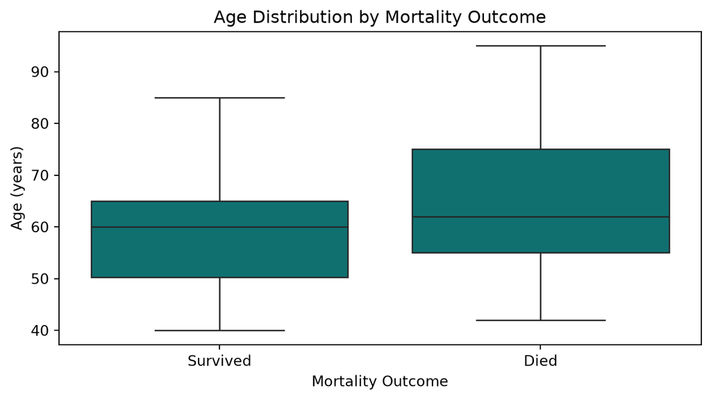

```python
plt.figure(figsize=(7, 4))

sns.boxplot(data=train_df, x="DEATH_EVENT", y="age",color=plot_color)

plt.title("Age Distribution by Mortality Outcome")
plt.xlabel("Mortality Outcome")
plt.ylabel("Age (years)")
plt.xticks([0, 1], ["Survived", "Died"])

plt.tight_layout()
plt.show()
```

The median age of patients who died was slightly higher (approximately 62 years) than those who survived (60 years), and the patients who died also showed a wider age distribution. This suggests that older age may be associated with mortality in our dataset, although the overlap between the groups indicates that age alone may not distinguish mortality outcomes.

### Mortality by sex

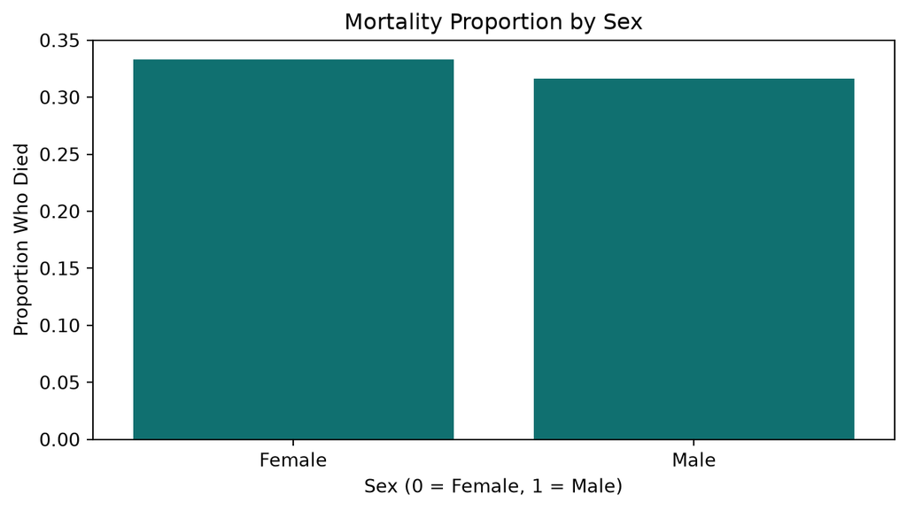

```python
mortality_by_sex = (
    train_df.groupby("sex")["DEATH_EVENT"]
    .mean()
    .reset_index()
)
plt.figure(figsize=(7, 4))
sns.barplot(data=mortality_by_sex, x="sex", y="DEATH_EVENT",color=plot_color)

plt.title("Mortality Proportion by Sex")
plt.xlabel("Sex (0 = Female, 1 = Male)")
plt.ylabel("Proportion Who Died")
plt.xticks([0, 1], ["Female", "Male"])

plt.tight_layout()
plt.show()
```

The mortality proportions are very similar between females (approximately 33%) and males (approximately 32%), suggesting that mortality rates do not differ substantially by sex in our training data. Despite males being more numerous in the dataset, the proportion of deaths within each sex is comparable, indicating that sex alone may have limited ability to distinguish mortality outcomes.

### Mortality by the levels of High Blood Pressure

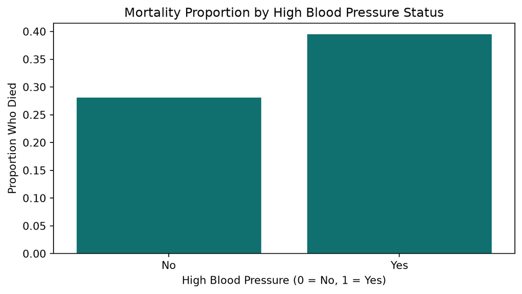

```python
mortality_by_bp = (
    train_df.groupby("high_blood_pressure")["DEATH_EVENT"]
    .mean()
    .reset_index()
)

plt.figure(figsize=(7, 4))

sns.barplot(
    data=mortality_by_bp,
    x="high_blood_pressure",
    y="DEATH_EVENT",
    color=plot_color
)

plt.title("Mortality Proportion by High Blood Pressure Status")
plt.xlabel("High Blood Pressure (0 = No, 1 = Yes)")
plt.ylabel("Proportion Who Died")
plt.xticks([0, 1], ["No", "Yes"])

plt.tight_layout()
plt.show()
```

Patients with recorded high blood pressure had a higher mortality proportion (approximately 40%) than those without high blood pressure (approximately 28%). Suggesting a potential association between high blood pressure and mortality in our training data, although the difference alone does not establish that high blood pressure causes increased mortality.

## Model Development

### Baseline Model

We first use a Dummy Classifier as a baseline to evaluate whether our classification model performs better than simply predicting the majority class.

```python
from sklearn.dummy import DummyClassifier

dummy_model = DummyClassifier(strategy="most_frequent")

dummy_model.fit(X_train, y_train)

dummy_pred = dummy_model.predict(X_test)
```

### Logistic Regression

We use logistic regression as a starting point because it is a standard model for predicting binary outcomes, such as mortality, from clinical measurements. We chose a simple model because our training set has only 239 observations, and a more complex model would be more likely to overfit. Finally, StandardScaler is applied to standardize the features before model training.

```python
from sklearn.linear_model import LogisticRegression
from sklearn.preprocessing import StandardScaler
from sklearn.pipeline import make_pipeline

logistic_model = make_pipeline(
    StandardScaler(),
    LogisticRegression(max_iter=1000, random_state=522)
)

logistic_model.fit(X_train, y_train)

logistic_pred = logistic_model.predict(X_test)
```

## Model Evaluation

We evaluate the Dummy Classifier and Logistic Regression using stratified 5-fold cross-validation on the training data. We compare accuracy, recall, and F1-score to assess their predictive performance.

- **Accuracy** measures the proportion of all predictions that are correct. It gives an overall comparison with the baseline, but the baseline can score reasonably well by always predicting survival because survivors are the majority.
- **Recall** measures the proportion of observed deaths that the model correctly identifies. Low recall means the model misses many patients who died during follow-up.
- **F1-score** is the harmonic mean of precision and recall for the death class. It rewards identifying more observed deaths while also accounting for false positives, which reduce precision.

```python
from sklearn.model_selection import StratifiedKFold, cross_validate
import pandas as pd

cv = StratifiedKFold(
    n_splits=5,
    shuffle=True,
    random_state=522
)

models = {
    "Dummy Classifier": dummy_model,
    "Logistic Regression": logistic_model
}

results = []

for name, model in models.items():
    scores = cross_validate(
        model,
        X_train,
        y_train,
        cv=cv,
        scoring=["accuracy", "recall", "f1"]
    )

    results.append({
        "Model": name,
        "Accuracy": scores["test_accuracy"].mean(),
        "Recall": scores["test_recall"].mean(),
        "F1-score": scores["test_f1"].mean()
    })

results_df = pd.DataFrame(results)

print(results_df.round(3).to_string(index=False))
```

```
              Model  Accuracy  Recall  F1-score
   Dummy Classifier     0.678   0.000      0.00
Logistic Regression     0.749   0.444      0.53
```

### Final Test Evaluation

After comparing the models using cross-validation, we evaluate Logistic Regression on the held-out test set.

```python
from sklearn.metrics import accuracy_score, recall_score, f1_score, confusion_matrix

test_pred = logistic_model.predict(X_test)

print("Test Accuracy:", round(accuracy_score(y_test, test_pred), 3))
print("Test Recall:", round(recall_score(y_test, test_pred), 3))
print("Test F1-score:", round(f1_score(y_test, test_pred), 3))

print("\nConfusion Matrix:")
print(confusion_matrix(y_test, test_pred))
```

```
Test Accuracy: 0.733
Test Recall: 0.421
Test F1-score: 0.5

Confusion Matrix:
[[36  5]
 [11  8]]
```

# Results

## Classification Results

```python
results_df.round(3)
```

Table 1: Mean 5-fold cross-validation scores on the training set.

|  | Model | Accuracy | Recall | F1-score |
| --- | --- | --- | --- | --- |
| 0 | Dummy Classifier | 0.678 | 0.000 | 0.00 |
| 1 | Logistic Regression | 0.749 | 0.444 | 0.53 |

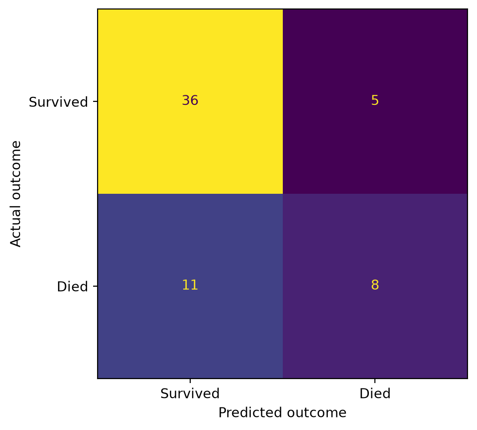

Figure 1: Confusion matrix of the logistic regression model on the test set.

```python
from sklearn.metrics import ConfusionMatrixDisplay
ConfusionMatrixDisplay.from_predictions(
    y_test, test_pred, display_labels=["Survived", "Died"], colorbar=False
)
plt.xlabel("Predicted outcome")
plt.ylabel("Actual outcome")
plt.show()
```

We first compared a baseline Dummy Classifier with Logistic Regression using stratified 5-fold cross-validation on the training set (Table 1). Logistic Regression achieved a mean accuracy of 74.9%, recall of 44.4% and F1-score of 0.530. The Dummy Classifier, which always predicts survival, achieved 67.8% accuracy but a recall and F1-score of zero, because it never identifies a death.

On the held-out test set, Logistic Regression achieved an accuracy of 73.3%, recall of 42.1% and F1-score of 0.500. As shown in Figure 1, the model correctly identified 8 of the 19 patients who died, but missed the other 11. It also flagged 5 patients who survived as at risk of death, so of the 13 patients the model flagged, 8 actually died. These results suggest that clinical measurements carry some useful information about mortality, but the low recall shows the model misses most patients who died.

# Discussion

Our research question was whether we can predict if a patient with heart failure will die during the follow-up period using their clinical characteristics. Our logistic regression model did better than the baseline model, which always predicts that the patient survives. However, the model is not good enough to answer our question with confidence. On the test set, it had an accuracy of 73.3%, but this is only a little higher than the 67.8% accuracy the baseline got by never predicting a death. More importantly, the recall was 42.1%: the model correctly identified only 8 of the 19 patients who died, and missed the other 11.

In a real clinical setting, missing a patient who later dies is much worse than flagging a patient who survives. A missed patient might not get closer follow-up or changes to their treatment in time. If our model were used to decide which patients need more attention, more than half of the patients at highest risk would be missed. Our exploratory analysis helps explain why. Patients who died were slightly older and more often had high blood pressure, but the two groups overlapped a lot, and the death rate was almost the same for men and women. This means no single measurement clearly separated patients who died from those who survived, which made the prediction difficult.

We expected the model to perform better, because previous studies with this data set found that serum creatinine and ejection fraction can predict survival well (Chicco and Jurman 2020) and identified several significant risk factors (Ahmad et al. 2017). The low recall suggests that a simple logistic regression with the default settings is not enough to capture these relationships, or that our test set was too small to show the model’s real performance.

Our analysis has several limitations. The data set is small (299 patients) and comes from a single hospital in Pakistan, and all patients had advanced heart failure (NYHA class III or IV), so our results may not apply to patients with milder disease or to other populations. Our test set had only 19 deaths, so our recall estimate could change a lot with a different split. We used the default classification threshold of 0.5, which is not ideal when missing a death is more costly than a false alarm. We kept the extreme values of creatinine phosphokinase and platelets because they may be real measurements, but they could affect the model. Finally, our model shows associations, not causes: for example, it cannot tell us that high blood pressure causes death.

Because of the low recall, our model should not be used on its own to make decisions about patient care. At most, it could support clinicians as one extra piece of information, together with their own judgement. A better model could help hospitals decide which patients need closer follow-up and earlier treatment, which matters because treatment that follows clinical guidelines can extend life but takes months to show its full benefit (Cardiac Services BC, n.d.).

This work leads to several future questions. Could lowering the classification threshold increase recall without creating too many false alarms? Would other models, such as random forests, perform better? Which clinical measurements contribute most to the model’s predictions? And would a model trained on a larger data set, from several hospitals and with patients at different stages of heart failure, perform better and apply more broadly?

# References

Ahmad, Tanvir, Assia Munir, Sajjad Haider Bhatti, Muhammad Aftab, and Muhammad Ali Raza. 2017. “Survival Analysis of Heart Failure Patients: A Case Study.” *PLOS ONE* 12 (7): e0181001. https://doi.org/10.1371/journal.pone.0181001.

American Heart Association. n.d. *Classes and Stages of Heart Failure*. [Https://www.heart.org/en/health-topics/heart-failure/what-is-heart-failure/classes-of-heart-failure](https://www.heart.org/en/health-topics/heart-failure/what-is-heart-failure/classes-of-heart-failure). https://www.heart.org/en/health-topics/heart-failure/what-is-heart-failure/classes-of-heart-failure.

BC Ministry of Health. 2023. *Heart Failure – Diagnosis and Management*. BC Guidelines. https://www2.gov.bc.ca/gov/content/health/practitioner-professional-resources/bc-guidelines/heart-failure-chronic.

Cardiac Services BC. n.d. *Heart Failure*. https://www.cardiacbc.ca/health-info/heart-failure.

Chicco, Davide, and Giuseppe Jurman. 2020. “Machine Learning Can Predict Survival of Patients with Heart Failure from Serum Creatinine and Ejection Fraction Alone.” *BMC Medical Informatics and Decision Making* 20: 16. https://doi.org/10.1186/s12911-020-1023-5.

*Heart Failure Clinical Records*. 2020. UCI Machine Learning Repository. https://doi.org/10.24432/C5Z89R.